# Praca domowa 1 - eksploracja danych German Credit Data

## Paweł Koźmiński

```python
import pandas as pd
import numpy as np
import sklearn
import matplotlib as plt
import seaborn as sns
import matplotlib.pyplot as plt
```

```python
gcdata = pd.read_csv("https://www.mldata.io/download-csv-weka/german_credit_data/")
print(gcdata.head())
```

```
  checking_account_status  duration credit_history purpose  credit_amount  \
0                     A11         6            A34     A43         1169.0
1                     A12        48            A32     A43         5951.0
2                     A14        12            A34     A46         2096.0
3                     A11        42            A32     A42         7882.0
4                     A11        24            A33     A40         4870.0

  savings present_employment  installment_rate personal other_debtors  ...  \
0     A65                A75               4.0      A93          A101  ...
1     A61                A73               2.0      A92          A101  ...
2     A61                A74               2.0      A93          A101  ...
3     A61                A74               2.0      A93          A103  ...
4     A61                A73               3.0      A93          A101  ...

   property   age  other_installment_plans housing existing_credits   job  \
0      A121  67.0                     A143    A152              2.0  A173
1      A121  22.0                     A143    A152              1.0  A173
2      A121  49.0                     A143    A152              1.0  A172
3      A122  45.0                     A143    A153              1.0  A173
4      A124  53.0                     A143    A153              2.0  A173

  dependents  telephone foreign_worker customer_type
0          1       A192           A201             1
1          1       A191           A201             2
2          2       A191           A201             1
3          2       A191           A201             1
4          2       A191           A201             2

[5 rows x 21 columns]
```

```python
np.random.seed(123)
gcdata.info()
```

```
<class 'pandas.core.frame.DataFrame'>
RangeIndex: 1000 entries, 0 to 999
Data columns (total 21 columns):
checking_account_status    1000 non-null object
duration                   1000 non-null int64
credit_history             1000 non-null object
purpose                    1000 non-null object
credit_amount              1000 non-null float64
savings                    1000 non-null object
present_employment         1000 non-null object
installment_rate           1000 non-null float64
personal                   1000 non-null object
other_debtors              1000 non-null object
present_residence          1000 non-null float64
property                   1000 non-null object
age                        1000 non-null float64
other_installment_plans    1000 non-null object
housing                    1000 non-null object
existing_credits           1000 non-null float64
job                        1000 non-null object
dependents                 1000 non-null int64
telephone                  1000 non-null object
foreign_worker             1000 non-null object
customer_type              1000 non-null int64
dtypes: float64(5), int64(3), object(13)
memory usage: 164.1+ KB
```

Wprawdzie braków brak - za to większość z danych nie jest liczbowa

```python
gcdata.describe()
```

|  | duration | credit_amount | installment_rate | present_residence | age | existing_credits | dependents | customer_type |
| --- | --- | --- | --- | --- | --- | --- | --- | --- |
| count | 1000.000000 | 1000.000000 | 1000.000000 | 1000.000000 | 1000.000000 | 1000.000000 | 1000.000000 | 1000.000000 |
| mean | 20.903000 | 3271.258000 | 2.973000 | 2.845000 | 35.546000 | 1.407000 | 1.155000 | 1.300000 |
| std | 12.058814 | 2822.736876 | 1.118715 | 1.103718 | 11.375469 | 0.577654 | 0.362086 | 0.458487 |
| min | 4.000000 | 250.000000 | 1.000000 | 1.000000 | 19.000000 | 1.000000 | 1.000000 | 1.000000 |
| 25% | 12.000000 | 1365.500000 | 2.000000 | 2.000000 | 27.000000 | 1.000000 | 1.000000 | 1.000000 |
| 50% | 18.000000 | 2319.500000 | 3.000000 | 3.000000 | 33.000000 | 1.000000 | 1.000000 | 1.000000 |
| 75% | 24.000000 | 3972.250000 | 4.000000 | 4.000000 | 42.000000 | 2.000000 | 1.000000 | 2.000000 |
| max | 72.000000 | 18424.000000 | 4.000000 | 4.000000 | 75.000000 | 4.000000 | 2.000000 | 2.000000 |

Warto zauważyć, że kolumny `installment_rate`, `present_residence`, `dependents`, `customer_type` są najprawdopodniej kategoryczne (dokumentacja na stronie nie przekazuje pełni informacji nt. danych)

```
Text(0.5,1,'Rozklad wieku wsrod osob starajacych sie o kredyt')
```

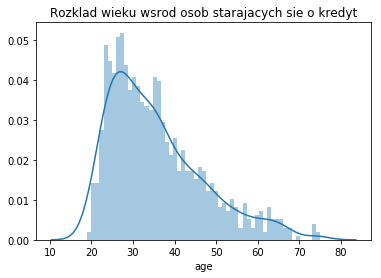

```python
age_dens = sns.distplot(gcdata.age, bins = 75-18)
age_dens.set_title('Rozklad wieku wsrod osob starajacych sie o kredyt')
```

Widzimy, że rozkład wieku wśród biorących kredyty charakteryzuje się wysoką, dodatnią skośnością, a najwięcej jest osób w wieku ok. 23-28 lat.

```python
gcdata.savings.value_counts()
```

```
A61    603
A65    183
A62    103
A63     63
A64     48
Name: savings, dtype: int64
```

Oznaczenia: A61 - < 100 DM (prawdopodobnie Deutsche Mark); A65 - unknown/no savings; A62 - <100, 500); A63 - <500, 1000); A64 - >=1000 Ponieważ obserwacji jest dokładnie 1000 - łatwo policzyć sobie procenty udziałów poszczególnych kategorii.

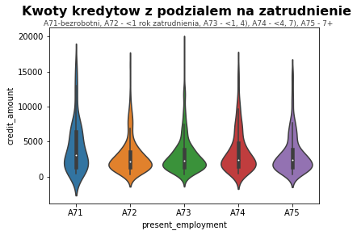

```python
gcd_violin = sns.violinplot(gcdata.present_employment, gcdata.credit_amount,
                            order = ['A71', 'A72', 'A73', 'A74', 'A75'])
#gcd_violin.set_title('Rozklad kwot zaciaganych kredytow z podzialem na zatrudnienie')
plt.text(x=-1, y=23000, s='Kwoty kredytow z podzialem na zatrudnienie', fontsize=16, weight='bold')
plt.text(x=-0.6, y=21500, s='A71-bezrobotni, A72 - <1 rok zatrudnienia, A73 - <1, 4), A74 - <4, 7), A75 - 7+',
         fontsize=9, alpha=0.75)
plt.show()
```

Wśród wszystkich grup podziału zatrudnienia, najwięcej kredytów branych jest na kwotę 0-5000 DM, jendak najmniejszy procent kreedytów branych w tym przedziale jest wśród osób... bezrobotnych.

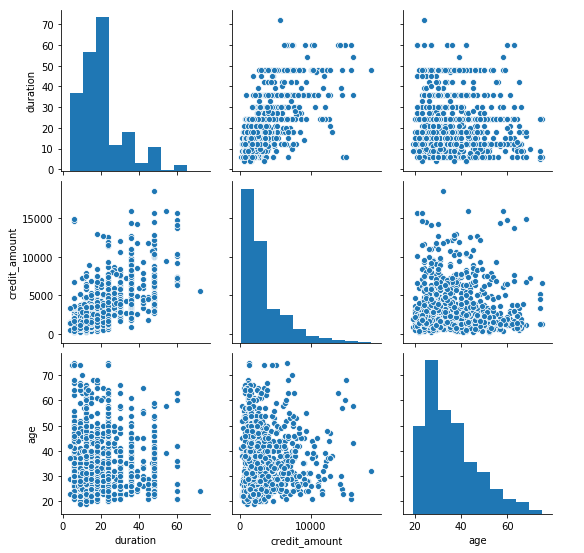

```python
sns.pairplot(gcdata[["duration", "credit_amount", "age"]])
```

Interesujaca kwestia: Jak historia kredytowa wpływa na ocenę klienta?

```
Text(0.5,0.98,'Liczba ocen wiarygodnosci klientow z podzialem na grupy historii kredytowej')
```

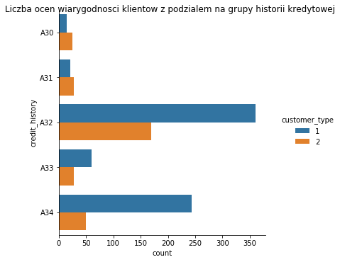

```python
cat = sns.catplot(y = "credit_history", hue = "customer_type", kind = "count",  data = gcdata,
            order = ["A30", "A31", "A32", "A33", "A34"])
cat.fig.suptitle("Liczba ocen wiarygodnosci klientow z podzialem na grupy historii kredytowej")
```

A30 - brak kredytów w historii lub wszystkie spłacane w terminie  
A31 - wszystkie kredyty w danym banku spłacane terminowo  
A32 - aktualne kredyty dotychczas spłacane terminowo  
A33 - opóźnienie w spłacaniu w przeszłości  
A34 - konto niepokojący / istnieją kredyty w innych bankach

```python
print(gcdata.groupby("credit_history")["customer_type"].mean()-1)
```

```
credit_history
A30    0.625000
A31    0.571429
A32    0.318868
A33    0.318182
A34    0.170648
Name: customer_type, dtype: float64
```

Powyżej widzimy odsetek osób, które zostały negatywnie ocenione w poszczególnych grupach klientów ze względu na historię kredytową.

```python
from scipy.stats import chi2_contingency
for i in gcdata.select_dtypes(include=['float64', 'int64']).columns:
    d=np.hstack([pd.DataFrame(gcdata.customer_type), gcdata[i].values.reshape(-1,1)])
    p_value=chi2_contingency(d)[1]
    if p_value<0.1:
        print('%s - ISTOTNA' %i)
    else:
        print ('%s - NIEISTOTNA' %i)
```

```
duration - NIEISTOTNA
credit_amount - ISTOTNA
installment_rate - NIEISTOTNA
present_residence - NIEISTOTNA
age - NIEISTOTNA
existing_credits - NIEISTOTNA
dependents - NIEISTOTNA
customer_type - NIEISTOTNA
```

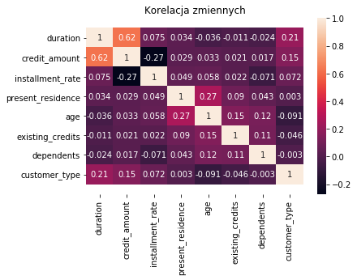

```python
cor = gcdata.corr()
corplot = sns.heatmap(cor, annot = True)
bottom, top = corplot.get_ylim()
corplot.set_ylim(bottom + 0.5, top - 0.5)
corplot.set_title('Korelacja zmiennych')
plt.show()
```

Oczywiscie jest to korelacja tylko zmiennych liczbowych, żadna para jednak nie jest od siebie silnie zależna.

# Próba zamiany zmiennych kategorycznych na liczbowe factory

```python
from sklearn.preprocessing import LabelEncoder
from sklearn.preprocessing import OneHotEncoder

le = LabelEncoder()
integer_encoded = le.fit_transform(gcdata["savings"])
print(integer_encoded)
#invert
#print(le.inverse_transform(integer_encoded))
```

```
[4 0 0 0 0 4 2 0 3 0 0 0 0 0 0 1 4 4 0 2 0 2 0 1 4 0 0 3 0 0 3 0 1 4 0 0 0
 0 0 0 2 2 0 1 0 0 2 2 0 1 4 0 0 4 0 4 4 0 0 0 0 4 0 0 0 4 0 3 0 4 0 4 0 0
 4 0 0 0 4 0 4 2 1 0 0 0 0 1 1 0 0 0 4 4 3 0 4 1 0 4 1 0 0 0 4 0 0 0 4 2 1
 0 0 0 2 4 4 4 2 2 0 0 0 0 4 0 0 0 0 0 4 0 0 0 1 4 3 2 4 0 3 0 0 0 0 1 0 1
 0 3 1 0 0 3 1 0 1 0 1 4 1 0 2 0 2 2 0 3 0 0 0 0 0 0 0 4 0 2 0 0 0 0 4 3 0
 0 0 0 1 0 3 1 0 0 1 0 0 1 4 0 2 0 0 0 0 0 0 0 0 3 4 4 0 0 4 4 0 0 0 0 0 4
 0 4 0 0 3 0 0 0 0 2 1 0 0 0 4 1 0 0 4 0 0 0 2 0 0 1 0 0 3 0 0 1 4 4 0 0 1
 1 0 0 0 0 0 0 4 0 0 4 4 2 4 0 0 0 0 4 0 1 3 0 4 4 1 0 0 1 0 0 0 0 0 0 4 0
 4 4 0 3 0 0 4 0 2 3 4 1 0 0 4 1 0 0 4 0 0 4 0 0 0 0 0 3 0 0 4 3 0 0 0 1 1
 1 0 0 0 4 0 0 0 0 2 0 0 0 0 2 1 3 0 0 4 0 2 0 4 0 0 0 4 4 0 0 0 0 0 0 0 0
 4 0 0 4 1 0 0 4 0 1 4 0 4 0 1 0 4 0 2 0 0 3 0 0 0 1 0 0 0 3 0 4 0 0 4 0 4
 0 2 2 0 0 0 2 4 0 0 4 2 4 3 4 0 1 4 0 0 3 0 0 0 0 0 0 0 4 2 3 0 0 0 0 0 0
 0 4 0 0 4 3 4 0 0 0 0 0 0 0 0 0 0 0 0 4 0 0 0 4 0 0 1 0 0 4 0 0 2 0 1 0 0
 0 3 3 2 0 0 0 1 0 0 0 1 4 0 4 1 0 0 1 0 0 1 1 0 4 2 1 0 1 0 0 0 0 4 0 0 0
 1 4 0 0 0 1 0 0 1 0 0 0 0 1 0 1 4 0 4 0 0 0 0 0 4 0 0 0 0 0 0 4 4 2 0 1 0
 0 1 4 0 0 4 0 0 4 4 1 0 3 4 0 0 0 4 0 0 0 0 4 0 0 0 0 0 0 4 0 0 0 0 0 0 4
 3 0 4 1 0 0 0 0 0 0 0 0 0 2 0 1 0 4 1 1 3 0 0 4 4 0 1 0 0 0 4 0 0 4 0 1 2
 4 0 0 4 0 0 0 2 0 0 0 0 0 1 0 0 4 0 2 0 0 0 0 0 1 0 0 0 4 0 0 0 4 0 0 0 0
 3 0 0 0 1 1 0 2 2 0 0 1 0 0 0 4 0 0 1 4 4 1 1 3 0 1 1 4 0 2 0 0 0 0 2 0 1
 1 0 2 1 0 0 0 2 0 4 0 0 4 4 0 4 1 0 3 0 2 0 3 2 0 0 3 0 0 0 3 0 4 0 1 0 1
 1 0 4 2 4 0 0 0 4 0 0 0 1 0 3 4 0 4 0 0 4 0 0 4 1 0 0 4 0 0 4 0 0 1 2 4 0
 0 3 0 0 3 0 1 4 3 2 4 0 0 0 4 4 0 2 1 4 0 4 4 0 0 0 4 4 0 0 4 0 0 0 0 0 0
 0 0 2 0 0 0 0 0 0 0 0 0 0 0 4 4 2 0 0 4 0 0 4 0 0 0 0 0 0 0 0 4 4 0 0 0 0
 4 0 0 0 1 4 0 0 1 3 0 0 3 0 2 0 0 4 0 2 0 1 4 0 3 0 0 0 4 0 4 4 0 0 0 4 0
 0 4 0 0 0 0 4 4 0 3 4 0 0 4 4 4 0 0 4 4 0 4 0 0 4 3 0 0 1 0 1 0 0 2 0 0 0
 0 0 0 4 0 0 0 0 2 0 1 0 0 0 4 4 0 4 0 0 2 2 4 0 1 0 0 2 0 0 3 4 0 0 1 0 0
 4 2 0 4 2 0 4 0 1 0 0 0 0 2 0 4 0 1 0 0 1 0 0 0 0 1 0 0 4 1 4 0 4 0 0 0 0
 1]
```

```python
cat_encoded = gcdata.select_dtypes(exclude = "object")
for i in gcdata.select_dtypes(include = "object").columns:
    f = pd.Series(le.fit_transform(gcdata[i]))
    cat_encoded = pd.concat([cat_encoded.reset_index(drop = True), f], axis = 1)
```

```python
cat_encoded.columns = cat_encoded.columns[0:8].tolist() + gcdata.select_dtypes(include = "object").columns.tolist()
print(cat_encoded.head())
```

```
   duration  credit_amount  installment_rate  present_residence   age  \
0         6         1169.0               4.0                4.0  67.0
1        48         5951.0               2.0                2.0  22.0
2        12         2096.0               2.0                3.0  49.0
3        42         7882.0               2.0                4.0  45.0
4        24         4870.0               3.0                4.0  53.0

   existing_credits  dependents  customer_type  checking_account_status  \
0               2.0           1              1                        0
1               1.0           1              2                        1
2               1.0           2              1                        3
3               1.0           2              1                        0
4               2.0           2              2                        0

   credit_history  ...  savings  present_employment  personal  other_debtors  \
0               4  ...        4                   4         2              0
1               2  ...        0                   2         1              0
2               4  ...        0                   3         2              0
3               2  ...        0                   3         2              2
4               3  ...        0                   2         2              0

   property  other_installment_plans  housing  job  telephone  foreign_worker
0         0                        2        1    2          1               0
1         0                        2        1    2          0               0
2         0                        2        1    1          0               0
3         1                        2        2    2          0               0
4         3                        2        2    2          0               0

[5 rows x 21 columns]
```

```python
cor = cat_encoded.corr()
cor = cor>0.5
print(cor.sum()-1)
```

```
duration                   1
credit_amount              1
installment_rate           0
present_residence          0
age                        0
existing_credits           0
dependents                 0
customer_type              0
checking_account_status    0
credit_history             0
purpose                    0
savings                    0
present_employment         0
personal                   0
other_debtors              0
property                   0
other_installment_plans    0
housing                    0
job                        0
telephone                  0
foreign_worker             0
dtype: int64
```

Z powyższej tabeli możemy odczytać, że spośród wszystkich kolumn, jedynie pomiędzy duration i credit_amount występuje korelacja o wartości współczynnika większej niż pół, co zgodne jest z naszymi poprzednimi obserwacjami.

```python
import lens

ls = lens.summarise(gcdata)
```

```python
explorer = lens.explore(ls)
explorer.describe()
```

|  | checking_account_status | duration | credit_history | purpose | credit_amount | savings | present_employment | installment_rate | personal | other_debtors | present_residence | property | age | other_installment_plans | housing | existing_credits | job | dependents | telephone | foreign_worker | customer_type |
| --- | --- | --- | --- | --- | --- | --- | --- | --- | --- | --- | --- | --- | --- | --- | --- | --- | --- | --- | --- | --- | --- |
| desc | categorical | numeric | categorical | categorical | numeric | categorical | categorical | categorical | categorical | categorical | categorical | categorical | numeric | categorical | categorical | categorical | categorical | categorical | categorical | categorical | categorical |
| dtype | object | int64 | object | object | float64 | object | object | float64 | object | object | float64 | object | float64 | object | object | float64 | object | int64 | object | object | int64 |
| notnulls | 1000 | 1000 | 1000 | 1000 | 1000 | 1000 | 1000 | 1000 | 1000 | 1000 | 1000 | 1000 | 1000 | 1000 | 1000 | 1000 | 1000 | 1000 | 1000 | 1000 | 1000 |
| nulls | 0 | 0 | 0 | 0 | 0 | 0 | 0 | 0 | 0 | 0 | 0 | 0 | 0 | 0 | 0 | 0 | 0 | 0 | 0 | 0 | 0 |
| unique | 4 | 33 | 5 | 10 | 921 | 5 | 5 | 4 | 4 | 3 | 4 | 4 | 53 | 3 | 3 | 4 | 4 | 2 | 2 | 2 | 2 |

```python
explorer.column_details("age")
```

|  | age |
| --- | --- |
| desc | numeric |
| dtype | float64 |
| min | 19.0000 |
| max | 75.0000 |
| mean | 35.5460 |
| median | 33.0000 |
| std | 11.3755 |
| sum | 35546.0000 |
| IQR | 15.0000 |

```python
explorer.correlation()
```

|  | customer_type | duration | credit_amount | installment_rate | existing_credits | dependents | present_residence | age |
| --- | --- | --- | --- | --- | --- | --- | --- | --- |
| customer_type | 1.0000 | 0.2057 | 0.0871 | 0.0737 | -0.0473 | -0.0030 | 0.0026 | -0.1122 |
| duration | 0.2057 | 1.0000 | 0.6247 | 0.1180 | 0.0284 | -0.0433 | 0.0437 | -0.0363 |
| credit_amount | 0.0871 | 0.6247 | 1.0000 | -0.3131 | 0.0238 | 0.0418 | 0.0236 | 0.0263 |
| installment_rate | 0.0737 | 0.1180 | -0.3131 | 1.0000 | 0.0210 | -0.0725 | 0.0475 | 0.0722 |
| existing_credits | -0.0473 | 0.0284 | 0.0238 | 0.0210 | 1.0000 | 0.0970 | 0.0672 | 0.1413 |
| dependents | -0.0030 | -0.0433 | 0.0418 | -0.0725 | 0.0970 | 1.0000 | 0.0405 | 0.1907 |
| present_residence | 0.0026 | 0.0437 | 0.0236 | 0.0475 | 0.0672 | 0.0405 | 1.0000 | 0.2347 |
| age | -0.1122 | -0.0363 | 0.0263 | 0.0722 | 0.1413 | 0.1907 | 0.2347 | 1.0000 |

```python
#explorer.correlation_plot()
#explorer.distribution_plot('credit_amount')
#niestety przy wywołaniu pojawił się błąd - issue:
# https://github.com/facultyai/lens/issues/44
# nawet po instalowaniu plotly >4.0
```

```python
#explorer.pairwise_density_plot('age', 'dependents')
```

[output not shown]

```python
explorer.crosstab('present_employment', 'savings')
```

|  | A71 | A72 | A73 | A74 | A75 |
| --- | --- | --- | --- | --- | --- |
| A61 | 40 | 120 | 210 | 100 | 133 |
| A62 | 7 | 17 | 33 | 24 | 22 |
| A63 | 3 | 5 | 26 | 9 | 20 |
| A64 | 0 | 7 | 18 | 9 | 14 |
| A65 | 12 | 23 | 52 | 32 | 64 |

Powyższa tabelka wydaje się świetnym rozwiązaniem do porównania zależności między zmiennymi! Doskonale widać, że A71 - bezrobotni, o ile mają oszczędności, to raczej niewiekie (a już z pewnością nie ponad 1000 DM). Wśród innych grup zatrudnionych, rozkład oszczędności wygląda inaczej.

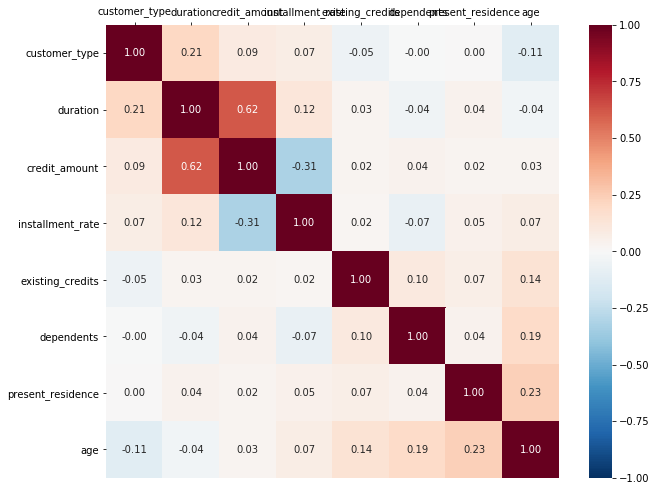

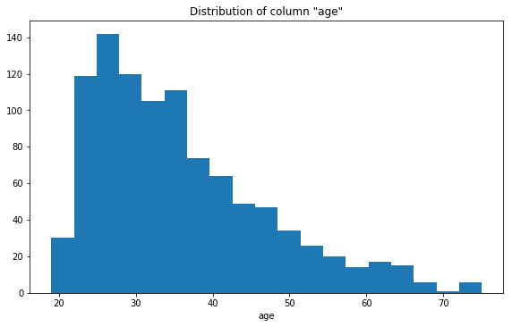

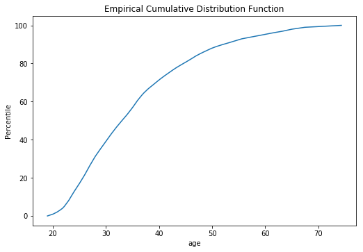

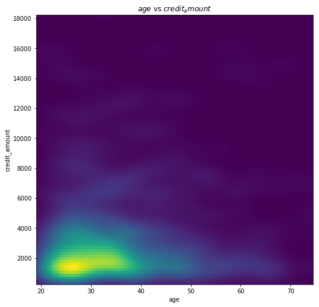

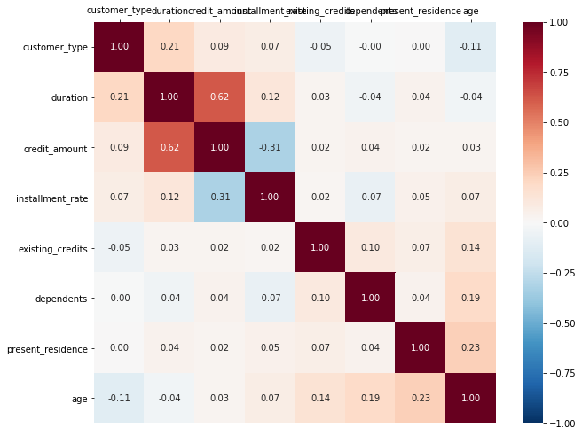

```python
lens.interactive_explore(ls)
```

Osobiście jestem pod wrażeniem narzędzia `interactive_explore()`. Uważam, że w znaczny sposób ułatwia ono wstępną eksplorację danych. Oczywiście nie jest ono idealne, nie da się manipulować, jakiego rodzaju wykresy wyświetlać w raporcie, jednak najważniejsze informacje, jak np. mapa ciepła korelacji, jest wyświetlana zawsze.

Ostatecznie, uważam, że narzędzie `lens` jest niezwykle użyteczną biblioteką, która w błyskawiczny sposób przedstawia podsumowanie zbioru danych, co może być przydatne gdy cenimy swój czas. Oczywiście nie wszystkie szczególy i zależności można w raporcie lens dostrzec, jednak stosunek informacji do poświęconego czasu istotnie robi wrażenie. Uważam, że jest to narzędzie godne polecenia.